# An Example Topic Model Script

Shawn Graham

Sept 29 2014

This is for an example of using Mimno’s wrapper for Mallet we’re using the sample data that comes bundeled when you download MALLET from http://mallet.cs.umass.edu/download.php we’ve assumed that, on Mac, you’ve put MALLET that you unzipped from Umass into a folder under [user], ie “shawngraham/mallet-2.0.7” on windows, use the full path “C:>\mallet-2.0.7\” insert the path to your documents between the quotation marks and windows users be sure to use \ instead of a single  
we’re assuming that you’ve already installed the mallet wrapper for R; if not, uncomment and run this line: install.packages(‘mallet’) if you are using Mavericks OS there could be a problem in installation - see chapter four for solution.

```r
require(mallet)
```

import the documents from the folder each document is here its own text file

```r
documents <- mallet.read.dir("mallet-2.0.7/sample-data/web/en/")
# windows users, remember: have the full path, ie "C:\\mallet-2.0.7\\sample-data\\web\\" and so on throughout this script

mallet.instances <- mallet.import(documents$id, documents$text, "mallet-2.0.7/stoplists/en.txt", token.regexp = "\\p{L}[\\p{L}\\p{P}]+\\p{L}")
```

create topic trainer object

```r
n.topics <- 10
topic.model <- MalletLDA(n.topics)
```

load documents

```r
topic.model$loadDocuments(mallet.instances)

## Get the vocabulary, and some statistics about word frequencies.
## These may be useful in further curating the stopword list.
vocabulary <- topic.model$getVocabulary()
word.freqs <- mallet.word.freqs(topic.model)
## Optimize hyperparameters every 20 iterations,
## after 50 burn-in iterations.
topic.model$setAlphaOptimization(20, 50)

## Now train a model. Note that hyperparameter optimization is on, by default.
## We can specify the number of iterations. Here we'll use a large-ish round number.
topic.model$train(200)

## NEW: run through a few iterations where we pick the best topic for each token,
## rather than sampling from the posterior distribution.
topic.model$maximize(10)
```

Get the probability of topics in documents and the probability of words in topics. By default, these functions return raw word counts. Here we want probabilities, so we normalize, and add “smoothing” so that nothing has exactly 0 probability.

```r
doc.topics <- mallet.doc.topics(topic.model, smoothed=T, normalized=T)
topic.words <- mallet.topic.words(topic.model, smoothed=T, normalized=T)  ##adap jockers wordcloud script to use this variable
```

from http://www.cs.princeton.edu/~mimno/R/clustertrees.R transpose and normalize the doc topics

```r
topic.docs <- t(doc.topics)
topic.docs <- topic.docs / rowSums(topic.docs)
write.csv(topic.docs, "topics-docs.csv" ) ## "C:\\Mallet-2.0.7\\topic-docs.csv"
```

Get a vector containing short names for the topics

```r
topics.labels <- rep("", n.topics)
for (topic in 1:n.topics) topics.labels[topic] <- paste(mallet.top.words(topic.model, topic.words[topic,], num.top.words=5)$words, collapse=" ")
```

have a look at keywords for each topic

```r
topics.labels
```

```
##  [1] "london needham thespis gilbert died"
##  [2] "equipartition theorem average energy system"
##  [3] "battle hawes union confederate kentucky"
##  [4] "rings system dust ring number"
##  [5] "gunnhild norway life king erik"
##  [6] "zinta indian film actress hindi"
##  [7] "yard national wilderness years park"
##  [8] "test hill australian cricket including"
##  [9] "sunderland echo world newspaper east"
## [10] "thylacine tasmanian extinct tiger back"
```

```r
write.csv(topics.labels, "topics-labels.csv") ## "C:\\Mallet-2.0.7\\topics-labels.csv")
```

Or we could do word clouds of the topics

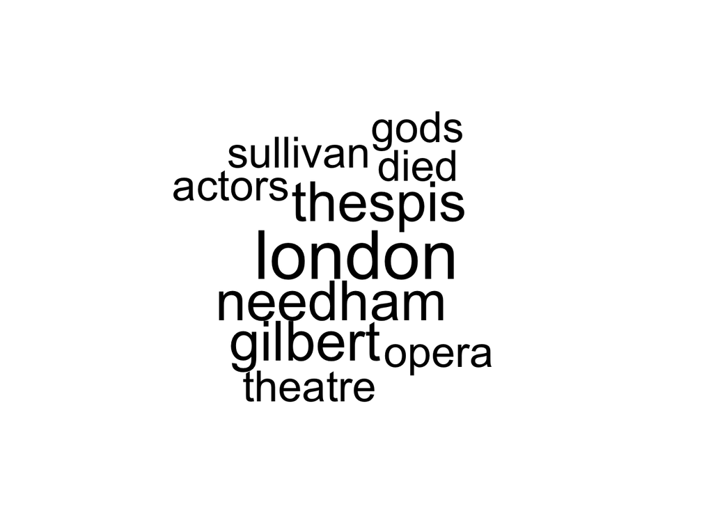

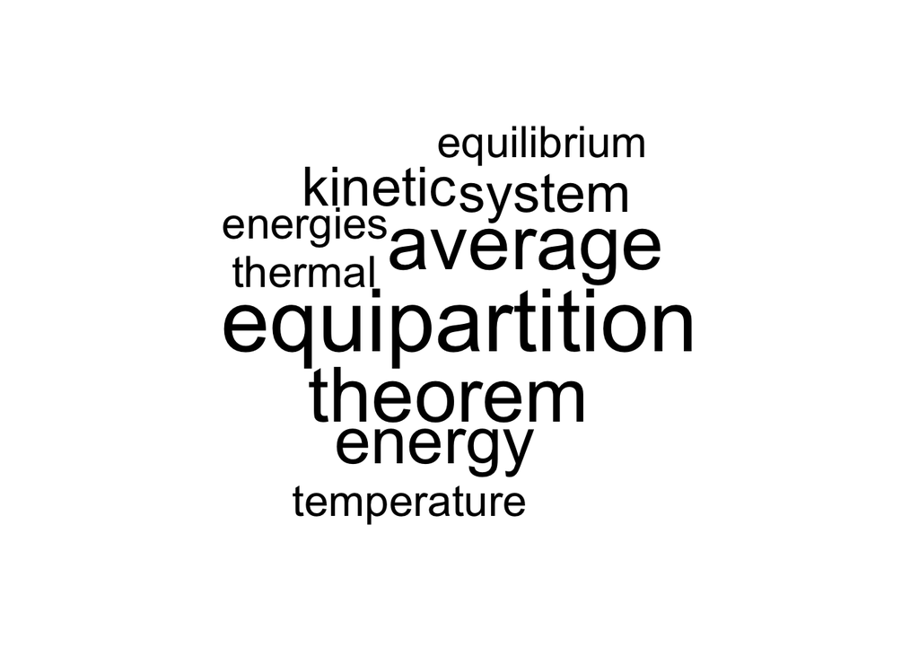

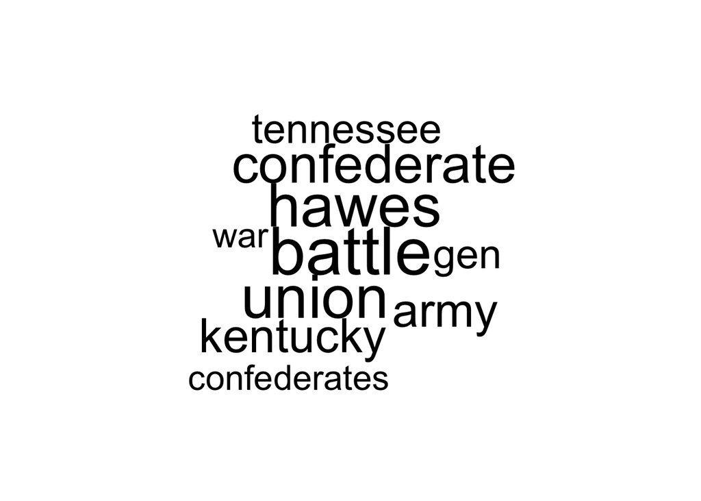

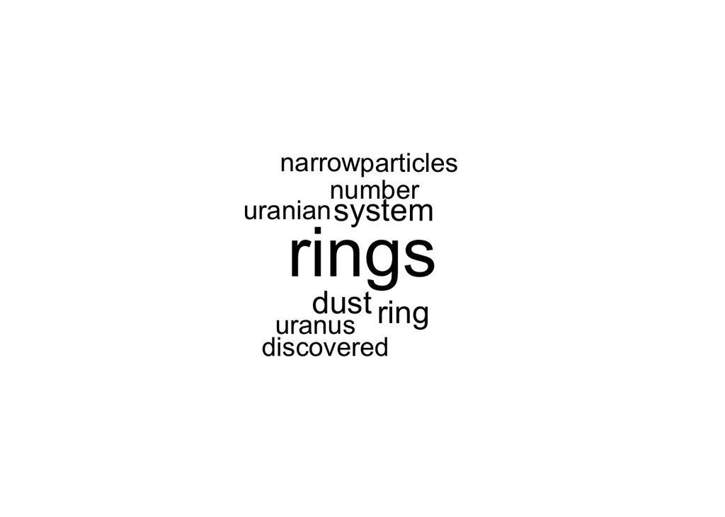

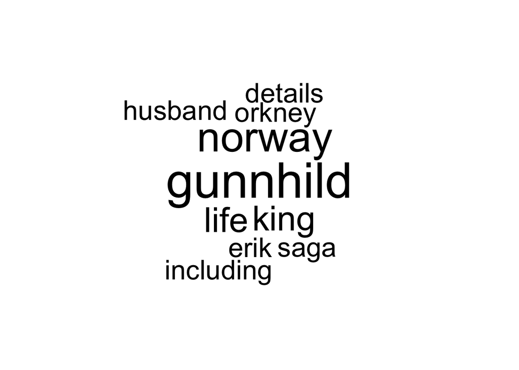

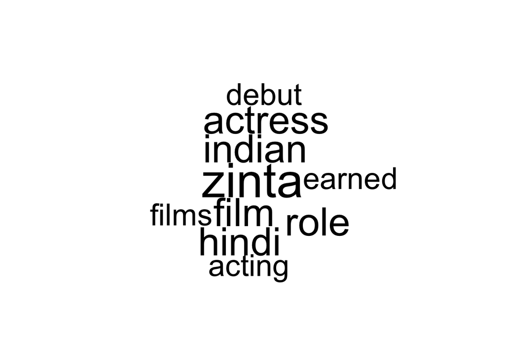

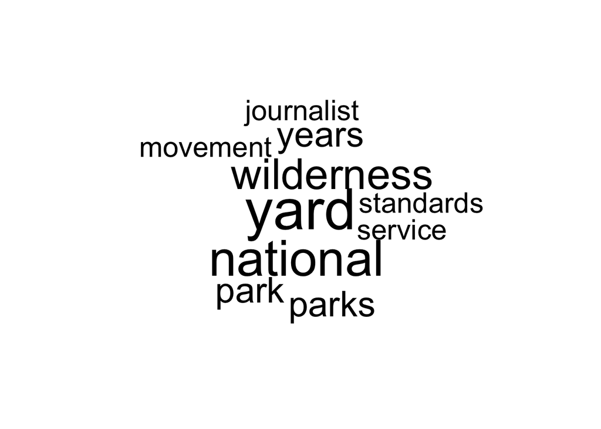

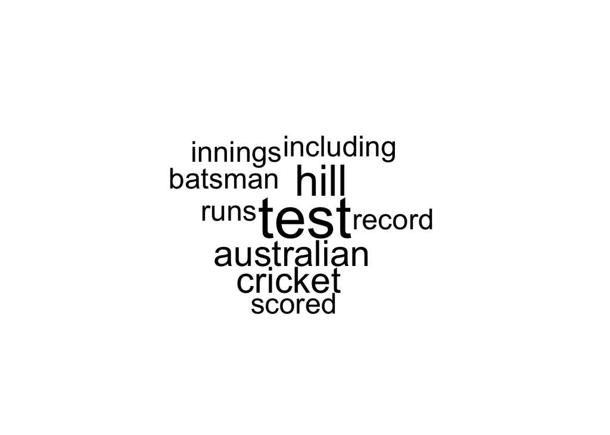

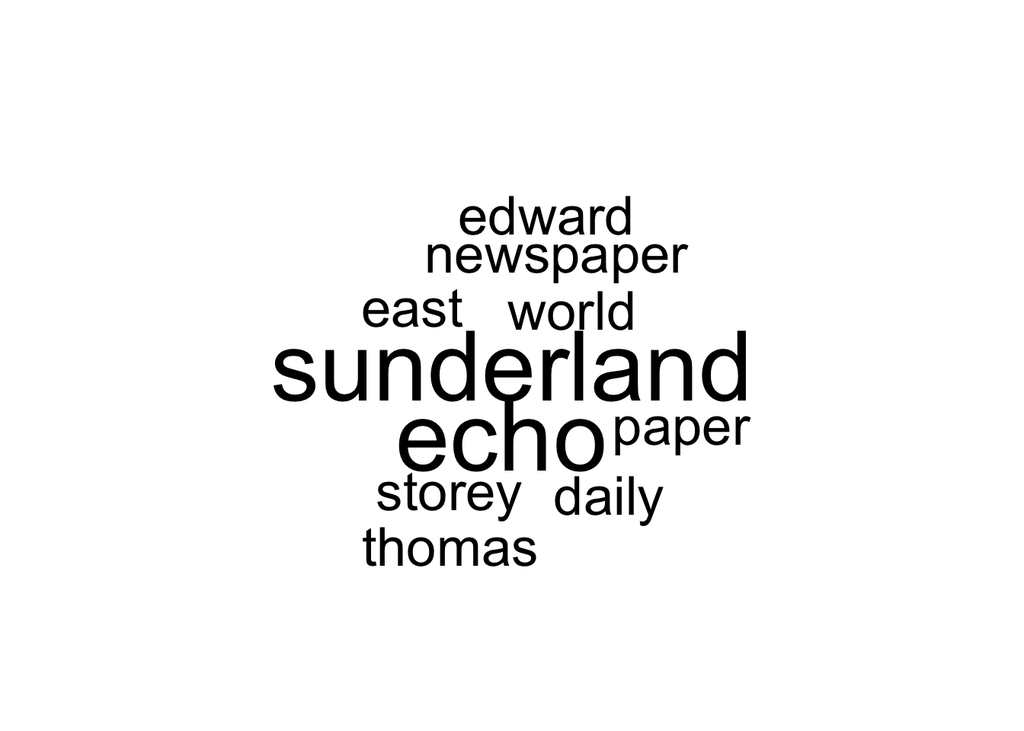

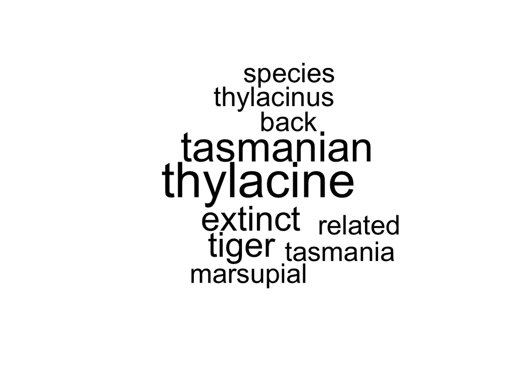

```r
library(wordcloud)
for(i in 1:10){
  topic.top.words <- mallet.top.words(topic.model,
                                      topic.words[i,], 10)
  print(wordcloud(topic.top.words$words,
                  topic.top.words$weights,
                  c(4,.8), rot.per=0,
                  random.order=F))
}
```